# Journey into the `tidyverse`

Dylan Titmuss

2024-07-22

## Premise:

This script explores and visualizes data examining the variation in pufflings’ growth rates based on their parents’ average time spent travelling to foraging grounds, hypothetically collected in 2022, 2023, and 2024.

#### `tidyverse` functions covered:

(Note that you very rarely need to know *which* `tidyverse` package any of these functions belongs to; I had to look most of these up.)

`ggplot2`::  
- `ggplot()`  
- `geom_histogram()`  
- `geom_boxplot()`  
- `geom_point()`  
- `geom_line()`  
- `geom_jitter()`  
- `geom_smooth()`  
- `geom_text()`  
- `geom_label()`  
- `aes()`  
- `position_dodge()`  
- `scale_*_discrete()`: `scale_x_discrete()`  
- `scale_*_continuous()`: `scale_y_continuous()`  
- `scale_*_manual()`: `scale_fill_manual()`  
- `facet_wrap()`  
- `coord_flip()`  
- `labs()`  
- `theme_*()`: `theme_linedraw()`, `theme_classic()`  
- `theme()`  
- `element_*()`: `element_blank()`, `element_text()`  
- `ggsave()`

`dplyr`::  
- `mutate()`  
- `group_by()`  
- `summarise()`/`summarize()`  
- `filter()`  
- `rowwise()`  
- `c_across()`  
- `across()`  
- `*_join()`: `left_join()`, `right_join()`  
- `join_by()`  
- `case_when()`  
- `n()`  
- `lag()`, `lead()`

`tidyr`::  
- `pivot_longer()`  
- `separate_wider_delim()`  
- `complete()`  
- `replace_na()`

`tidyselect`::  
- `starts_with()`  
- `everything()`

`stringr`::  
- `str_detect()`  
- `str_extract()`  
- `str_remove_all()`

`readr`::  
- `read_csv()`  
- `write_csv()`

`forcats`::  
- `as.factor()`

`magrittr`::  
- `%>%`

`glue`::  
- `glue()`

## Load packages

```r
# install.packages("tidyverse")

library(tidyverse) # this includes ggplot2, dplyr, tidyr, stringr, and more!
library(glue)
```

## Load data

```r
setwd("~/Desktop/Repos/2024-afo.sco.wos-tidyverse-workshop")

pufflings <- read_csv("data/puffling_weights.csv")
puffins <- read_csv("data/Fratercula_foraging.csv")
dates <- read_csv("data/Fratercula_sampling_dates.csv")
```

## Explore & tidy data

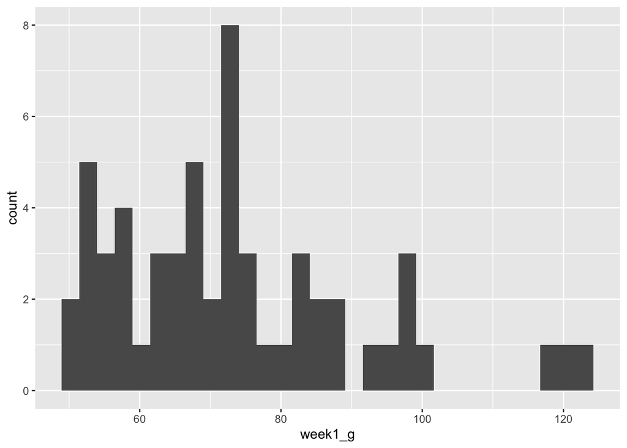

```r
# a very basic visual
ggplot() +
  geom_histogram(data = pufflings, aes(x = week1_g))
```

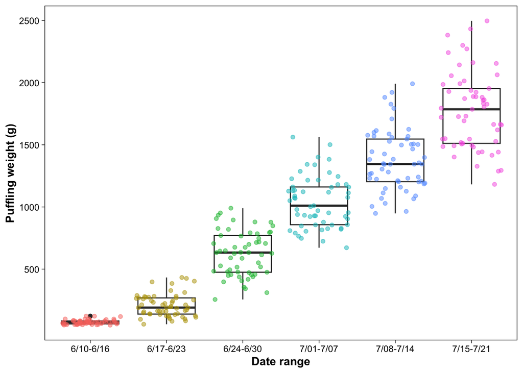

```r
pufflings <- pufflings %>%

  # "tidy" data by splitting each data point into its own row
  pivot_longer(cols = starts_with("week"),
               names_to = "week",
               values_to = "weight_g") %>%

  # intro to regular expressions: extract just the number out of each "weekX" label
  mutate(week = str_extract(week, "[0-9]"))

weeks <- dates %>%

  # "tidy" date data to prepare for further transformation
  pivot_longer(cols = everything(),
               names_to = "week",
               names_prefix = "week",   # this removes the specified prefix from each column name
               values_to = "date") %>%

  # output the first and last day in each week bracket
  group_by(week) %>%
  summarise(start = min(date),
            end = max(date)) %>%

  # create a new column from the above data
  mutate(label = glue("{start}-{end}")) # this is equivalent to `mutate(label = paste0(start, "-", end))`

# remove the leading zeros from the dates for ease of human-readability
weeks$label <- str_remove_all(weeks$label, "^0|(?<=-)0")

# create a more well-developed plot
ggplot(pufflings, aes(x = week, y = weight_g)) +
  # add a boxplot layer
  geom_boxplot() +

  # using the same data, layer points on top of boxplots & set the color variable to `week`
  # (this is more an aesthetic choice rather than particularly meaningful)
  geom_jitter(aes(col = week), alpha = 0.5) +

  # change the x-axis labels to those developed above
  scale_x_discrete(labels = weeks$label) +

  # change the y-axis scale
  scale_y_continuous(breaks = seq(500, 2500, by = 500)) +

  # change the axis labels
  labs(x = "Date range", y = "Puffling weight (g)") +

  # rotate the plot
  #coord_flip() +

  # change the theme
  theme_linedraw() +
  #theme_classic() +

  # customize particular aspects of the theme: remove the background grid and the (redundant) legend
  theme(panel.grid = element_blank(),
        axis.title = element_text(face = "bold"),
        legend.position = "none")
```

```r
ggsave("figures/puffling_growth.png", width = 6, height = 8, units = "in", dpi = 600)
```

## Let’s play with the adult foraging data frame

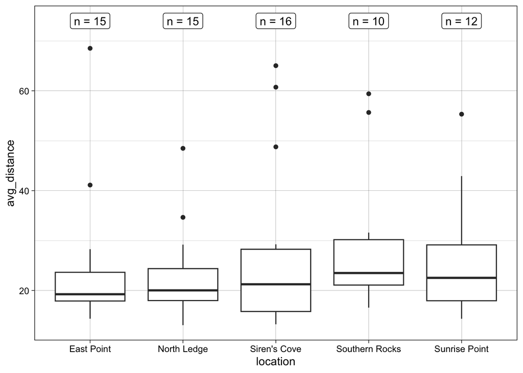

```r
# average each adult's foraging distances across all six weeks
puffin_avgs <- puffins %>%
  rowwise() %>%
  summarise(nest = nest,
            location = location,
            avg_distance = mean(c_across(starts_with("week"))))

sample_sizes <- puffin_avgs %>%
  group_by(location) %>%
  summarise(number = n())

ggplot(puffin_avgs, aes(x = location, y = avg_distance)) +
  geom_boxplot() +
  # geom_text(data = sample_sizes, aes(label = paste("n =", number),
  #                                    x = location,
  #                                    y = round(max(puffin_avgs$avg_distance, na.rm = TRUE)) + 5)) +
  geom_label(data = sample_sizes, aes(label = paste("n =", number),
                                     x = location,
                                     y = round(max(puffin_avgs$avg_distance, na.rm = TRUE)) + 5)) +
  theme_linedraw()
```

## Merge data frames & continue

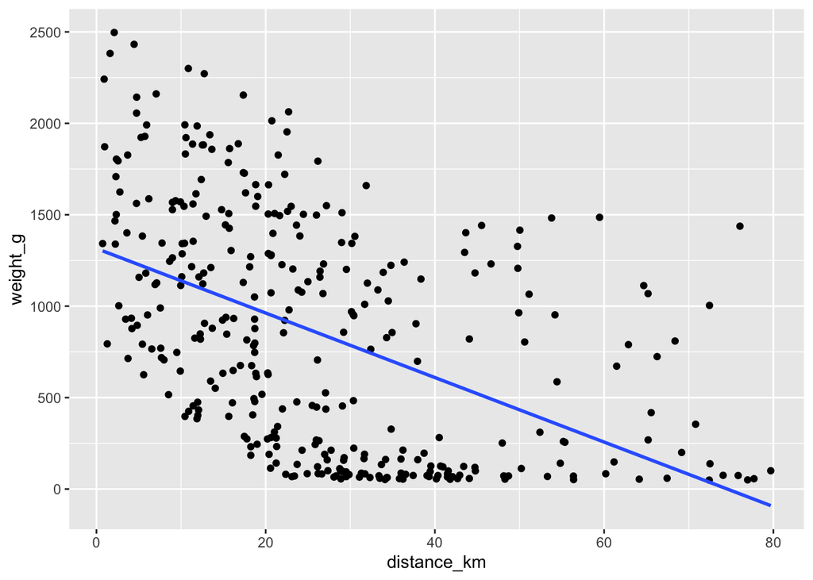

```r
# tidy adult puffin data
puffins <- pivot_longer(puffins,
                        cols = starts_with("week"),
                        names_to = "week",
                        values_to = "distance_km") %>%

  # extract digits from character strings
  mutate(week = str_extract(week, "[0-9]"))

# merge adult and puffling data frames by common variables
puffins_combined1 <- left_join(puffins, pufflings, join_by(nest == chick, location, week))

puffins_combined2 <- left_join(pufflings, puffins, join_by(chick == nest, location, week))

puffins_combined <- right_join(puffins, pufflings, join_by(nest == chick, location, week))

# visualize newly merged data
ggplot(puffins_combined, aes(x = distance_km, y = weight_g)) +
  geom_point() +

  # add a linear regression line
  geom_smooth(method = "lm", se = FALSE)
```

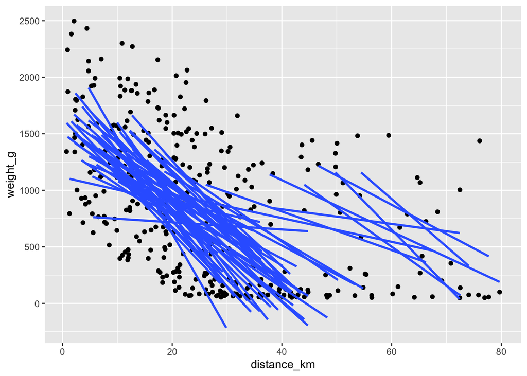

```r
# plot the same thing but creating separate trend lines for each nest
ggplot(puffins_combined, aes(x = distance_km, y = weight_g, group = nest)) +
  geom_point() +
  geom_smooth(method = "lm", se = FALSE)
```

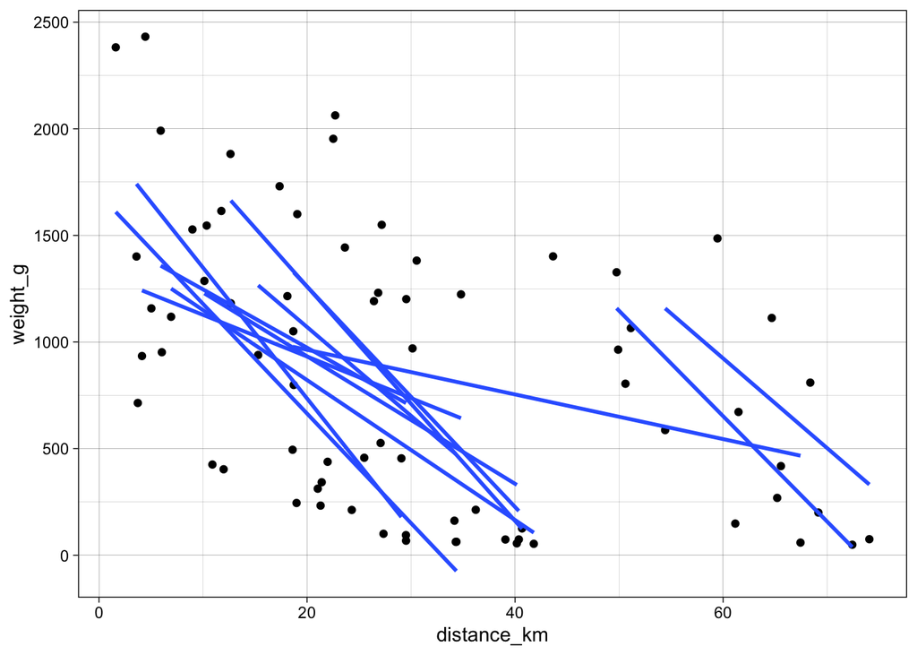

```r
puffins_combined %>%
  filter(location == "Siren's Cove") %>%
  ggplot(aes(x = distance_km, y = weight_g, group = nest)) +
  geom_point() +
  geom_smooth(method = "lm", se = FALSE) +
  theme_linedraw()
```

## Separate out years

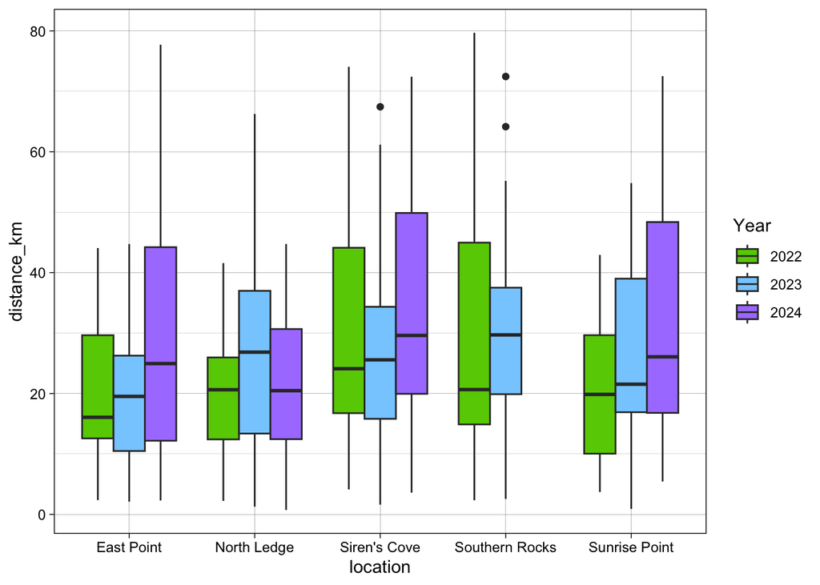

```r
puffins_combined <- puffins_combined %>%
  mutate(year = case_when(str_detect(nest, "A[A-Z]") ~ 2023,
                          str_detect(nest, "B[A-Z]") ~ 2024,
                          .default = 2022))

# plot annual variation in foraging distances
puffins_combined %>%

  # add in missing combination(s) of location & year for consistent boxplot spacing!
  complete(location, year) %>%

  # ^note that this above is piped directly into ggplot
  ggplot(aes(x = location, y = distance_km, fill = as.factor(year))) +
  geom_boxplot(position = position_dodge(preserve = "single")) +
  scale_fill_manual(values = c("chartreuse3", "skyblue1", "mediumpurple1"),
                    name = "Year") +
  theme_linedraw()
```

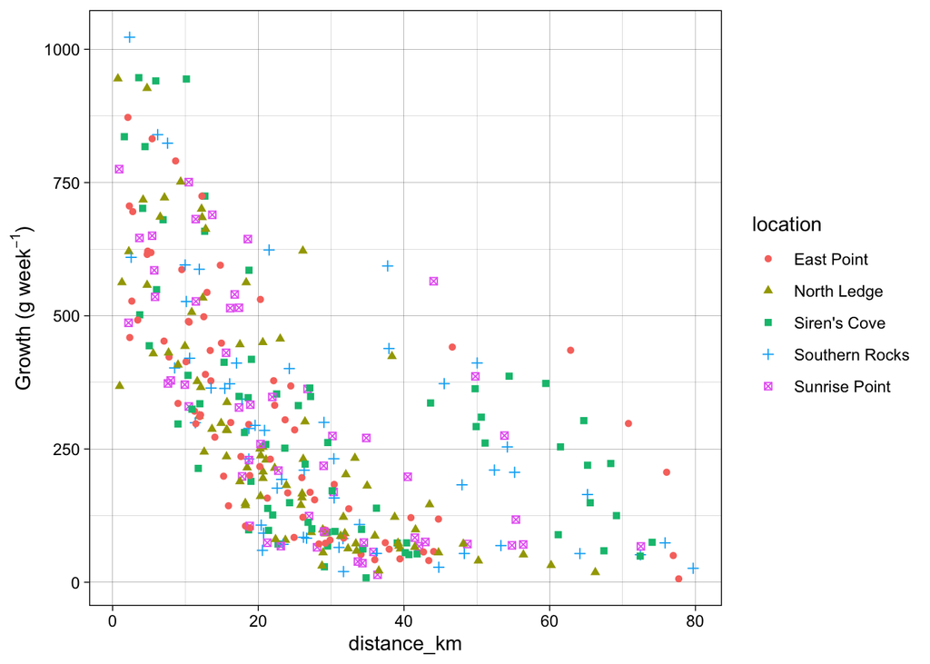

```r
# calculate the pufflings' weight change from week to week
puffins_combined <- puffins_combined %>%
  group_by(nest) %>%
  mutate(growth = weight_g - lag(weight_g)) %>%

  # fill NAs (first week at each nest) with first-week weight gain
  mutate(growth = replace_na(growth, weight_g[week == 1]))

# plot growth against distance; go over the difference b/w `aes(col = )` and `col = `
ggplot() +
  #geom_point(data = puffins_combined, aes(distance_km, growth), col = "orangered") +
  geom_point(data = puffins_combined, aes(distance_km, growth, col = location,
                                          shape = location)) +
  labs(y = "Growth (g/week)") +
  labs(y = expression("Growth (g week"^-1*")")) +
  theme_linedraw()
```

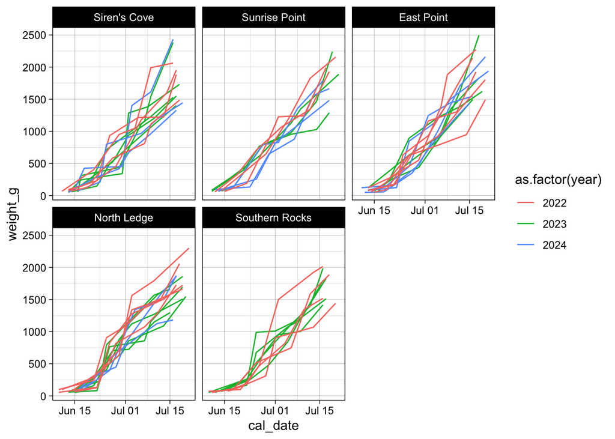

```r
# prepare to plot data by time
dates <- dates %>%
  # add years
  mutate(across(starts_with("week"),
                ~ case_when(str_detect(nest, "^[A-Z]$") ~ paste0(.x, "/2022"),
                            str_detect(nest, "^A[A-Z]") ~ paste0(.x, "/2023"),
                            str_detect(nest, "^B[A-Z]") ~ paste0(.x, "/2024")))) %>%
  mutate(across(starts_with("week"), ~ as.Date(.x, format = "%m/%d/%Y"))) %>%
  pivot_longer(cols = starts_with("week"),
               names_to = "week",
               names_prefix = "week",
               values_to = "date") %>%
  separate_wider_delim(date, delim = "-", names = c("year", "month", "day"),
                       cols_remove = FALSE) %>%
  mutate(year = as.numeric(year))

puffins_combined <- puffins_combined %>%
  left_join(dates) %>%  # without join_by(), all variables in common are used

  # creating fake date column for use in plotting
  mutate(cal_date = as.Date(paste0(month, "/", day), format = "%m/%d"))
write_csv(puffins_combined, "data/allPuffinData.csv")

ggplot() +
  geom_line(data = puffins_combined, aes(x = cal_date, y = weight_g, group = nest,
                                         col = as.factor(year))) +
  facet_wrap( ~ factor(location,
                       levels = unique(puffins_combined$location))) +
  theme_linedraw()
```

- `geom_col()` + `geom_errorbar()`
- `group_by() %>% filter(n() ...)`
- `distinct(.keep_all = TRUE)`
- `bind_rows()`
- `slice()`